# Underdog 12-Man Best Ball Fantasy Analysis (2024)

Jacob Bell

# 1) Overview/Introduction

This report aims to evaluate the differences in effectiveness of different draft strategies (e.g., Zero RB, Hero RB, Stacking) in ultimately making Round 2 in Underdog’s Best Ball Mania. If you are unfamiliar with Underdog Fantasy’s Best Ball Mania, I recommend understanding the differences between best ball leagues and a more traditional PPR redraft league.

While the main focus of the report is finding the best strategy to make Round 2, one makes Round 2 by scoring in the top two of 12 within Round 1 (Weeks 1-14). Even if you have above average scoring, you must have some luck to be in a league with others who are not above average to advance. With that being said, maximizing your score will ultimately maximize your chance of advancing to Round 2.

# 2) Determining Strategies

Each team can be split up in different ways by each position group. These are the terms and definitions I placed on each team by each position group. I divided WR and RB strategies into the first five groups and then QB and TE are divided into the last three.

- “Zero” - None of the position group within first 5 picks
- “Hero” - One of the position within only the first 2 and first 5
- “Heavy” - Three or more within the first 5 rounds
- “Weak” - One of the position within rounds 3 and 5
- “Balanced” - Two of the position within first 5 rounds
- “Elite” - One of the position within first rounds 5
- “Mid” - One of the position within rounds 6 and 8
- “Late” - Drafted after round 8

My logic behind round 5 is because of the value and impact of those players. In a regular non best-ball league, your first 5 picks are most likely starters for the majority of a season. Your draft strategy in those first 5 picks are fairly important as they are most likely to contribute the most points throughout the season(that’s why you drafted them right?). For QBs and TEs, the best of those positions get drafted between rounds 3 and 5. Middle of the pack of those positions typically have an ADP that land them in rounds 6 through 8. Also, the chosen rounds most evenly split strategies apart for each position.

# 3) Descriptive Results

Here, we will look at each strategy individually among each position group. From there, we will decide if they made a difference on the overall teams performance.

## 3.1) Team Points by Strategies

For the descriptive results, we can use confidence intervals to explain how some of the strategies work. A common trend among all position groups and strategy is that $n$ is a huge number which in turn decreases the standard error. Most of the confidence intervals are extremely precise being within 1-3 plus or minus of the mean due to this fact. As a result, we can estimate each strategy’s average performance with extremely high statistical precision. However, this shouldn’t be misinterpreted as consistency for individual teams. The standard deviation is still a somewhat big number typically around 100, meaning due to injuries, player performance, and other football factors, teams can still hugely fall outside of the confidence interval. The narrow confidence intervals speak to the ability to understand the average outcome, not the results of an individual team.

Non-Statistical English: Even though the averages are super precise, any single team’s outcome can be hugely different than the mean. Drafting the best or highest average scoring strategy doesn’t guarantee a good team.

### 3.1a) RB Strategy

From all of the strategies, Heavy RB appears to be on top. Heavy RB’s average score sat around 1,589 points with the next closest strategy being Balanced (2 RBs drafted) at a mean of 1,561. Heavy RB also has the least amount of $n$ out of any group meaning this is the least common RB draft strategy.

Zero RB performed the worst with a mean of 1,519 points. The Zero RB strategy also has the smallest standard deviation meaning the teams performed closer to the mean of 1,519. Hero RB was very close to last as well at a mean of 1,523.

With Heavy RB and Balanced being at the top and Zero and Hero RB being at the bottom in mean and confidence intervals, this suggests that drafting multiple RBs in the first 5 picks was very beneficial. Weak RB being somewhat in the middle is somewhat surprising. If taking a higher caliber RB in 1-2 didn’t perform quite well, drafting your first RB in rounds 3-5 wouldn’t make you assume that it’d do better. Weak RB being in the middle suggests that the players going in those rounds outperformed their ADP or they were undervalued.

In section 4.1, ANOVA testing will be used on the strategies to go deeper into if these differences are statistically meaningful.

Team Points by RB Strategy

| rbStrat | n | meanPoints | sdPoints | se | ci95Low | ci95High |
| --- | --- | --- | --- | --- | --- | --- |
| Balanced | 181791 | 1,561.9 | 132.4 | 0.3 | 1,561.3 | 1,562.5 |
| Heavy RB | 31560 | 1,589.4 | 129.6 | 0.7 | 1,588.0 | 1,590.8 |
| Hero RB | 167577 | 1,523.2 | 133.8 | 0.3 | 1,522.6 | 1,523.9 |
| Weak RB | 149645 | 1,551.5 | 126.3 | 0.3 | 1,550.9 | 1,552.1 |
| Zero RB | 142099 | 1,519.1 | 121.6 | 0.3 | 1,518.5 | 1,519.8 |

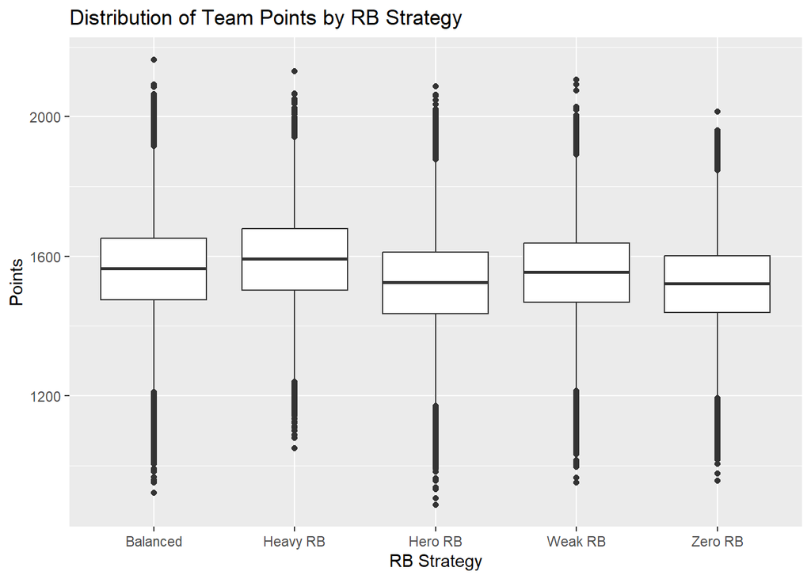

### 3.1b) WR Strategy

As discussed in RB strategy, we saw that drafting more than 2 running backs performed very well and drafting one or less in the first five rounds had a wide difference. WR strategy should be the inverse of the RB strategy. If someone were to have a RB Heavy strategy, they could at most only draft 2 WR’s. Factor in wanting an Elite QB and Elite TE and drafting a balanced WR room can become difficult to achieve.

With that being said, Zero and Hero WR were the best performing WR strategies with means of 1,582 and 1,581 points respectively. This agrees with the previous RB Heavy statistics since drafting more RBs decreases the amount of times WR is drafted. However, the amount of users drafting with less the one WR in the first 5 rounds is considerably small. There is still enough $n$ to be accurate with the confidence intervals for those strategies.

Heavy WR being the most common WR draft strategy is not surprising. Hero, Zero, and Weak RB easily allows for at least three WRs to be drafted in the first 5 rounds, and Balanced still allows for teams to draft three WRs. With Zero and Hero RB being the worst RB draft strategies, it makes sense for Heavy WR to perform the worst of the WR strategies. Heavy WR averages around to be 1,535 points which is 20 points less than the next worst which is Balanced.

Team Points by WR Strategy

| wrStrat | n | meanPoints | sdPoints | se | ci95Low | ci95High |
| --- | --- | --- | --- | --- | --- | --- |
| Balanced | 159931 | 1,555.8 | 133.1 | 0.3 | 1,555.1 | 1,556.4 |
| Heavy WR | 477664 | 1,535.2 | 129.1 | 0.2 | 1,534.9 | 1,535.6 |
| Hero WR | 17763 | 1,581.2 | 133.6 | 1.0 | 1,579.2 | 1,583.2 |
| Weak WR | 14275 | 1,567.0 | 127.5 | 1.1 | 1,564.9 | 1,569.0 |
| Zero WR | 3039 | 1,582.2 | 129.2 | 2.3 | 1,577.6 | 1,586.8 |

[figure not shown]

### 3.1c) QB Strategy

Team Points by QB Strategy

| qbStrat | n | meanPoints | sdPoints | se | ci95Low | ci95High |
| --- | --- | --- | --- | --- | --- | --- |
| Elite QB | 275474 | 1,542.6 | 132.7 | 0.3 | 1,542.1 | 1,543.1 |
| Late QB | 198176 | 1,541.6 | 124.6 | 0.3 | 1,541.0 | 1,542.1 |
| Mid QB | 199022 | 1,542.3 | 133.9 | 0.3 | 1,541.7 | 1,542.9 |

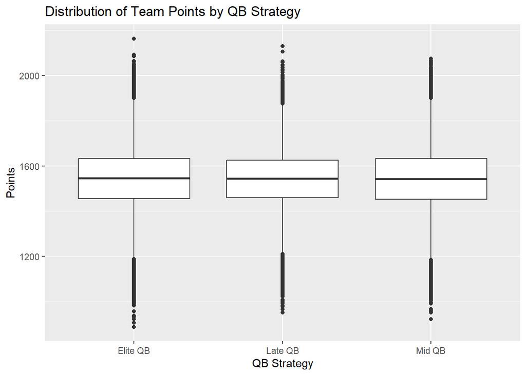

### 3.1d) TE Strategy

Although very slight, there are more teams drafting TEs in the first 5 rounds than a QB by about 25,000. The TE strategies have a slightly bigger difference than QB strategies. Drafting a late TE averaged out to be around 1,556 with Mid and Elite following behind by about 20ish points. with late TE performing better, it may suggest that there is a meaningful difference between TE strategies.

Team Points by TE Strategy

| teStrat | n | meanPoints | sdPoints | se | ci95Low | ci95High |
| --- | --- | --- | --- | --- | --- | --- |
| Elite TE | 304027 | 1,535.7 | 127.2 | 0.2 | 1,535.2 | 1,536.2 |
| Late TE | 180571 | 1,556.6 | 132.0 | 0.3 | 1,555.9 | 1,557.2 |
| Mid TE | 188074 | 1,538.9 | 134.0 | 0.3 | 1,538.3 | 1,539.5 |

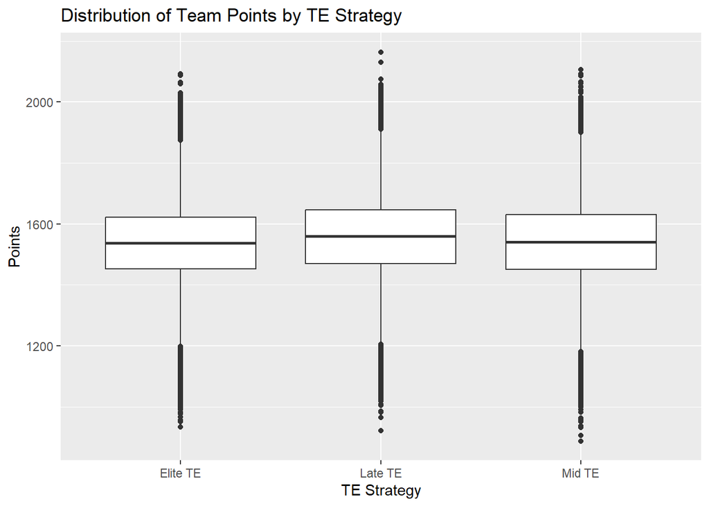

## 3.2) Round 2 Advancement by Strategies

Inherently, it may come across that analyzing Round 2 advancement after analyzing the points may be useless. However, if you’re drafting certain players through a certain strategy, you are making a smaller or larger player position pool based off your chose strategy. For example, if you were to draft more RB’s early, which has shown to be a strong strategy last year by points, you are ultimately making it harder for other teams to follow a similar strategy due to choosing more RB’s. This ultimately should lead to draft strategies points and advancement to have a positive correlation.

We can employ Chi squared tests to determine if the strategy choice is significant. If determined significant, we can use Tukey HSD to understand those differences among strategies.

### 3.2a) RB Strategies

As one would expect, there is a statistically significant association between RB strategy and making playoffs from Chi squared tests(X-squared = 9658, p = <2.2e-16). Meaning the likelihood of making playoffs depends on which RB strategy was used. Further analysis from standardized residuals shows what we said earlier with Heavy and Balanced RB strategies extremely over performed by making playoffs more times than expected. Zero and Hero RB also heavily under performed continuing the trend from previous tests. Weak RB slightly over performed which continues to suggest value in drafting the first RB after rounds 1-2.

```
##
##  Pearson's Chi-squared test
##
## data:  tableStrat
## X-squared = 9658.8, df = 4, p-value < 2.2e-16
```

#### Standardized Residuals

```
##
##                    0         1
##   Balanced -58.07077  58.07077
##   Heavy RB -54.21214  54.21214
##   Hero RB   39.00580 -39.00580
##   Weak RB  -12.79204  12.79204
##   Zero RB   62.96664 -62.96664
```

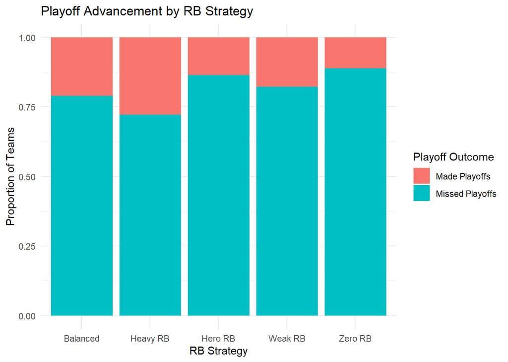

### 3.2b) WR Strategies

```
##
##  Pearson's Chi-squared test
##
## data:  tableStrat
## X-squared = 3663.2, df = 4, p-value < 2.2e-16
```

#### Standardized Residuals

```
##
##                    0         1
##   Balanced -39.30060  39.30060
##   Heavy WR  56.24145 -56.24145
##   Hero WR  -32.94256  32.94256
##   Weak WR  -17.54372  17.54372
##   Zero WR  -14.56225  14.56225
```

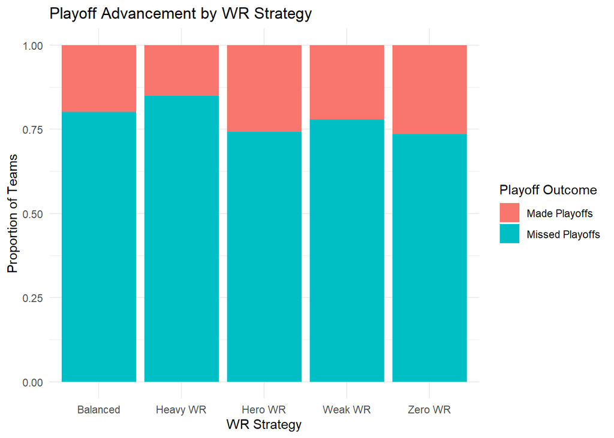

### 3.2c) QB Strategies

Again, performing the Chi Squared test also shows there is significant association between QB draft strategy and making the second round (X-squared = 342, p = <2.2e-16). The standardized residuals show that Elite and Mid QBs teams made round 2 more than expected, and Late QB was under performing by a wider margin. Drafting a QB late may mean you are allowing for high caliber QBs to slip further into the draft, and allowing teams to draft two good QBs before you draft one.

```
##
##  Pearson's Chi-squared test
##
## data:  tableStrat
## X-squared = 342.62, df = 2, p-value < 2.2e-16
```

#### Standardized Residuals

```
##
##                     0          1
##   Elite QB  -9.218980   9.218980
##   Late QB   18.489628 -18.489628
##   Mid QB    -8.534514   8.534514
```

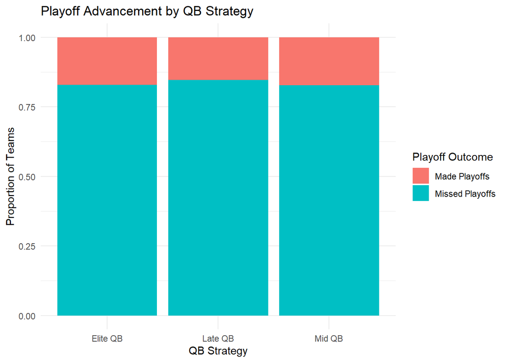

### 3.2d) TE Strategies

After performing the Chi Squared test for the final time, it also shows there is significant association between TE draft strategy and making the second round (X-squared = 2146, p = <2.2e-16). The standardized residuals show clear differences between each TE strategy. Drafting an Elite TE has a negative correlation with round 2 advancement. Drafting a Mid TE is within a very small range close to 0 implying that it does not make a huge difference on round 2 advancement. Finally, drafting a Late TE shows a strong positive correlation to making playoffs. These numbers suggest finding value in late rounds for your TE.

```
##
##  Pearson's Chi-squared test
##
## data:  tableStrat
## X-squared = 2146.9, df = 2, p-value < 2.2e-16
```

#### Standardized Residuals

```
##
##                      0           1
##   Elite TE  37.8917098 -37.8917098
##   Late TE  -43.1138941  43.1138941
##   Mid TE     0.5515912  -0.5515912
```

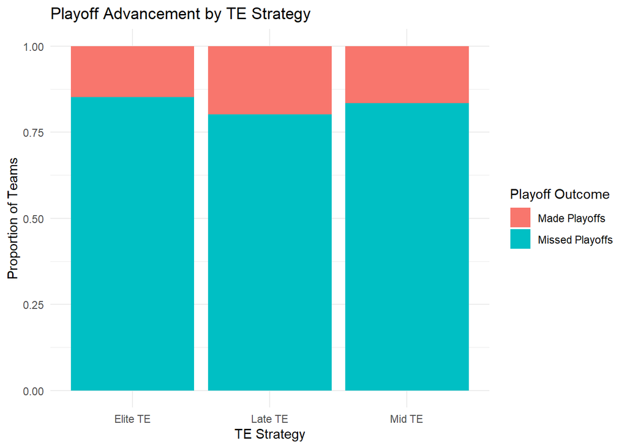

## 3.3) Team Points by Stacking

Firstly, the way stacking was generated could be flawed. The code determines who is WR1, WR2, and WR3 based off how they ranked on their team. Technically, if you were to draft a WR thinking they would be WR1 and they turned out to be WR3, that wasn’t necessarily your draft vision, but that is what the data below represents. For example, if you were to draft Stefon Diggs thinking he would be WR1 for some reason, he would be represented by WR3 since he scored the third most fantasy points for the Texans last year. So, the way the data is compiled is not perfect, but it can still provide some meaningful insight. Also, the table provided below filters by n > 40000. This means that draft strategies that are extremely uncommon will not show.

With that being said, drafting a team’s QB1-WR1-RB1-TE1 had the highest average with an average of 1,605. The table below does not show that stacking strategy due to it having an $n$ less than 40000. From the strategies that had an $n$ greater than 40000, stacking a team’s QB1 and RB1 has the highest average of around 1,570. QB1-RB1 and QB1-WR1 were both considerably higher than teams that didn’t stack by around an average of 20 points. QB1-RB2 teams under performed non-stacking teams by only 3 points. With most of the popular stacking strategies showing to outperform non-stacking teams, it could be said that stacking is beneficial to roster points.

Team Points by Stacking Strategy

| stackType | n | meanPoints | sdPoints | se | ci95Low | ci95High |
| --- | --- | --- | --- | --- | --- | --- |
| None | 47120 | 1,537.9 | 132.0 | 0.6 | 1,536.7 | 1,539.0 |
| RB1 | 53410 | 1,569.6 | 124.9 | 0.5 | 1,568.5 | 1,570.7 |
| RB2 | 40498 | 1,534.0 | 128.1 | 0.6 | 1,532.8 | 1,535.3 |
| TE1 | 96061 | 1,543.2 | 127.8 | 0.4 | 1,542.3 | 1,544.0 |
| TE1-WR1 | 44062 | 1,545.5 | 128.2 | 0.6 | 1,544.3 | 1,546.7 |
| TE1-WR2 | 41195 | 1,547.0 | 128.3 | 0.6 | 1,545.8 | 1,548.3 |
| WR1 | 168800 | 1,552.7 | 128.9 | 0.3 | 1,552.1 | 1,553.3 |
| WR2 | 122165 | 1,542.5 | 129.9 | 0.4 | 1,541.8 | 1,543.2 |
| WR3 | 77546 | 1,517.6 | 131.0 | 0.5 | 1,516.6 | 1,518.5 |

# 4) Infernetial Analysis / Anova

The ANOVA analysis will allow us to truly understand if the differences in means are statistically significant.

## 4.1) RB ANOVA Analysis

```
##                 Df    Sum Sq  Mean Sq F value Pr(>F)
## rbStrat          4 2.898e+08 72441835    4349 <2e-16 ***
## Residuals   672667 1.121e+10    16658
## ---
## Signif. codes:  0 '***' 0.001 '**' 0.01 '*' 0.05 '.' 0.1 ' ' 1
```

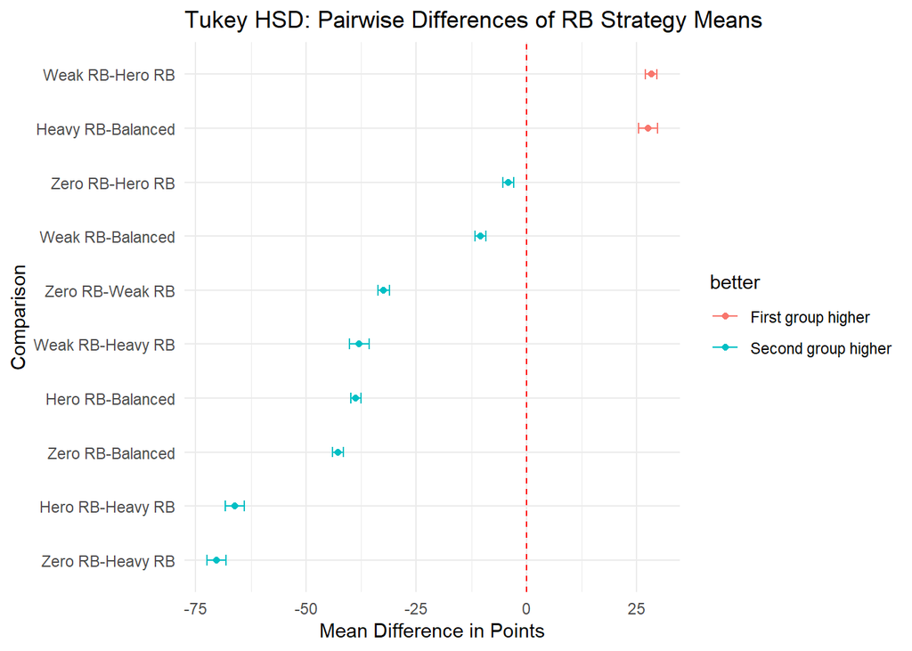

## 4.2) WR ANOVA Analysis

Turning to wide receiver strategies, the ANOVA results again reveal a highly significant effect on roster point outcomes. With an F value of 1376 and a p-value below 2e-16, we can confidently reject the null hypothesis that all WR strategy groups yield equal mean performance. The between-group variance (Mean Sq = 23M) is substantially greater than the within-group variance (17K), indicating that WR strategy accounts for a meaningful portion of the variation in total roster points.

```
##                 Df    Sum Sq  Mean Sq F value Pr(>F)
## wrStrat          4 9.332e+07 23329649    1376 <2e-16 ***
## Residuals   672667 1.140e+10    16950
## ---
## Signif. codes:  0 '***' 0.001 '**' 0.01 '*' 0.05 '.' 0.1 ' ' 1
```

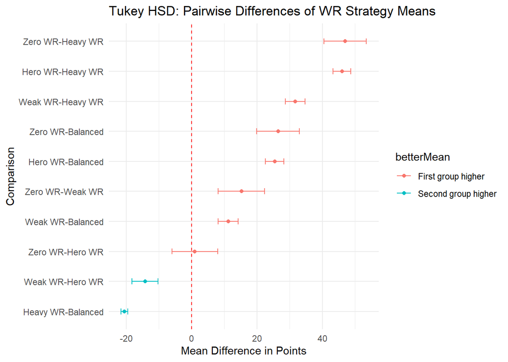

## 4.3) QB ANOVA Analysis

QB strategy shows a statistically significant effect on roster point outcomes, with an F-value of 3.514 and a p-value of 0.0298. However, the between-group variance (Mean Sq = 60K) is only modestly larger than the within-group variance (17K), suggesting that while QB strategy does influence performance, its impact is considerably smaller than that of RB or WR strategy.

```
##                 Df    Sum Sq Mean Sq F value Pr(>F)
## qbStrat          2 1.201e+05   60050   3.514 0.0298 *
## Residuals   672669 1.149e+10   17088
## ---
## Signif. codes:  0 '***' 0.001 '**' 0.01 '*' 0.05 '.' 0.1 ' ' 1
```

As shown in the confidence intervals, there are slight differences in the impact of the strategies. The Tukey HSD shows that Elite QB was the highest in roster points means and only slight edging out Mid QB. Again, these are averages, so in reality these teams can over and under perform the average. However, with the means being similar, this suggests that when a QB is selected is not a heavy indicator of roster points. Thus, fantasy managers have more flexibility when selecting their quarterback.

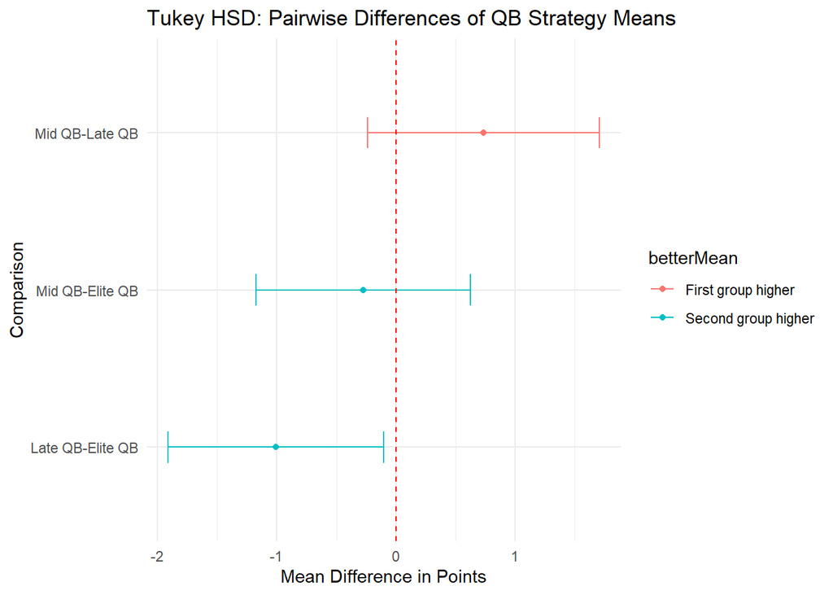

## 4.4) TE ANOVA Analysis

Finally, the TEs round out the end. The ANOVA results once again demonstrate a highly significant effect on roster points outcomes. The F value is at 1530 and the p-value is well below again at less than 2e-16. We can yet again reject the null hypothesis that all TE strategy groups yield equal mean performance. The between-group variance(Mean Sq = 26M) far exceeds the within-group variance (17K), indicating the TE strategy is a meaningful portion of the variation in total roster points.

```
##                 Df    Sum Sq  Mean Sq F value Pr(>F)
## teStrat          2 5.204e+07 26020387    1530 <2e-16 ***
## Residuals   672669 1.144e+10    17011
## ---
## Signif. codes:  0 '***' 0.001 '**' 0.01 '*' 0.05 '.' 0.1 ' ' 1
```

Due to statistical significance, we can once again proceed with the Tukey HSD to compare TE strategies. Similar to the other position groups, it produces clear differences. Late TE outpeforms Elite and Mid TE. Then, Mid TE outperforms Elite TE by a few points. The graph below signifies the importance of drafting a Late TE for roster points.

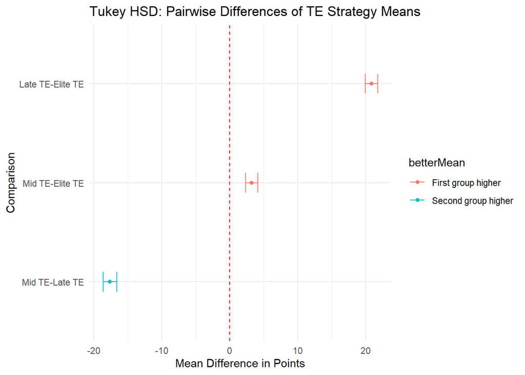

# 5) Multivariate Model

To quantify the individual impact of each positional draft strategy on total roster points, we fit a linear model with roster points as the outcome and the strategy types for each position as predictors. This approach allows us to estimate the marginal effect of each strategy while adjusting for others.

The intercept group is made of Balanced WR, Balanced RB, Elite QB, and Elite TE. The linear model suggests that the strongest strategy last year was Heavy RB, Hero WR, Elite QB, and Late TE.

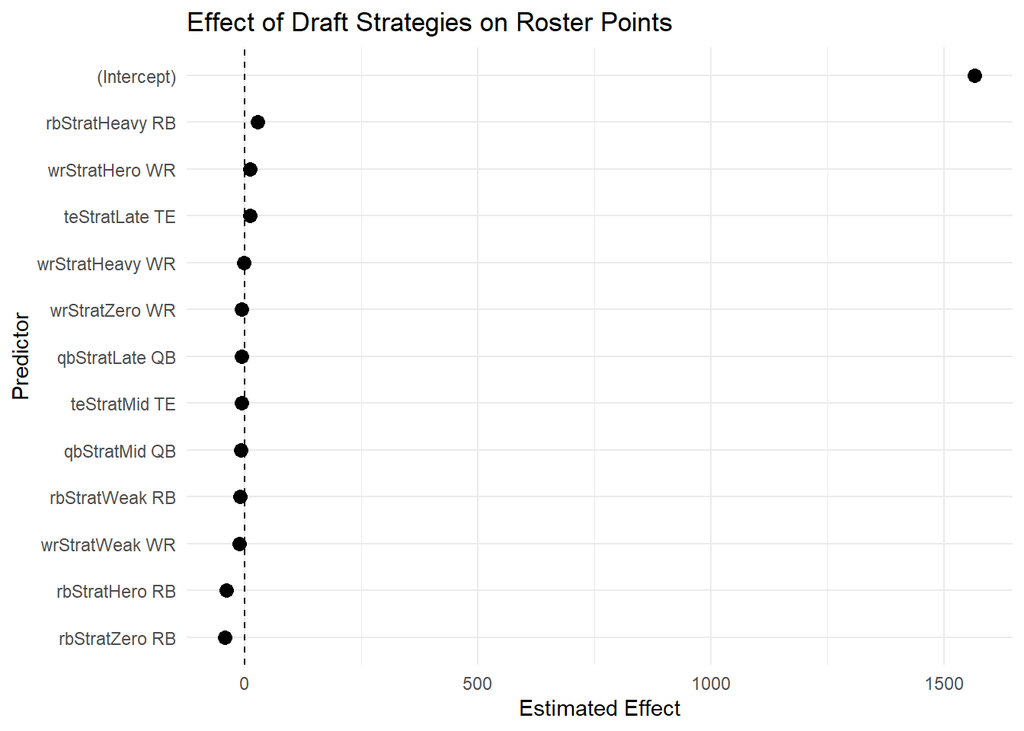

# 6) Final Conclusions / Discussion

Is there anything you can take away for a regular fantasy league with a waiver wire? It depends. If you are taking part in a half-PPR league, drafting RBs if they’re good value can be promising. At the same time, you will have access to the waivers, so there is less pressure in making sure your starting RBs are the best like in a Best Ball. In a full-PPR league, definitely look towards grabbing those elite WRs in the early rounds. Switching from half-PPR to full-PPR is a huge swing in balance for RBs and WRs. Taking advantage of that fact is crucial for your draft strategy.

Tight ends with higher ADP performed below their expected rank. Sam LaPorta, Travis Kelce, and Mark Andrews under performed their projections, and they were also the most commonly drafted before round 5. If they were to perform to their projection, I could easily believe Elite TE could be a better strategy. However, drafting an Elite TE and having them perform to their rank I believe is more difficult than waiting for a later round TE and expecting them to outperform their rank.

With that being said, I’d expect WR and RB impact to stay consistent year over year. Until Underdog Fantasy users realize that RBs are way more valuable in half-PPR, RBs will continue getting the edge throughout the season. QBs I imagine will stay relatively the same. I believe they are the most consistent position group, so drafting a high-value or low-value QB will give you about the results they are projected most times. TEs are a little more tricky. The numbers somewhat support that higher end TEs didn’t perform to their projections, and that really hurt users teams. That fact, however, can definitely change from year to year. Is it worth gambling on that fact or better just to grab a different position that is more consistent?

Future work for next year would include doing a deeper dive into the different stacking strategies. I believe that they could prove to be very beneficial when drafting high caliber combinations. Also, determining the amount of each position group can prove to be insightful. For position groups like TE and QB, most managers only draft 2-3 each of those positions. Having an injury to either group can severely hinder performance as there are less players to pick from for points.

# 7) Quick Points

# 8) Acknowledgements

Having the Underdog Fantasy spreadsheets allowed me to have a very fun experience compiling and diving into the different draft strategies https://underdognetwork.com/football/best-ball-research/best-ball-mania-v-downloadable-pick-by-pick-data-2024. Thank you to sports reference for providing fantasy football spreadsheets as well which were used in some of the data compilation (https://www.pro-football-reference.com/years/2024/fantasy.htm). Huge thanks to Logan McDaniel for helping me.